# Understanding Cyclistic Bike-share Customers - A Data Analysis Case Study

Samuel Owusu Kontor

2023/04/30

## Introduction:

As a junior data analyst in the marketing analyst team at Cyclistic, a bike-share company in Chicago, I was tasked with understanding the usage patterns of casual riders and annual members of Cyclistic’s bike-share program. The director of marketing believes that the future success of Cyclistic hinges on increasing the number of annual memberships, and my team has been tasked with designing a new marketing strategy to convert casual riders to annual members.

To ensure our recommendations are backed by compelling data insights and professional data visualizations, Cyclistic executives must approve them. Therefore, my team and I are taking a data-driven approach to this project using the five phases of data analysis - ASK, PREPARE, PROCESS, ANALYZE and SHARE.

In this documentation, I will outline the steps taken to understand the usage patterns of Cyclistic’s bike-share program, with a focus on identifying differences between casual riders and annual members. Through this analysis, I aim to provide insights that will inform the design of a new marketing strategy to convert casual riders to annual members, driving the future success of Cyclistic.

## Stage 1: Ask

#### Problem:

The marketing analyst team at Cyclistic wants to understand how annual members and casual riders use Cyclistic bikes differently so that they can design a marketing strategy to convert casual riders into annual members. The team wants to identify the differences between these two groups and what motivates casual riders to become members.

##### Business Task:

The business task is to understand how annual members and casual riders use Cyclistic bikes differently in order to design a new marketing strategy aimed at converting casual riders into annual members, which is believed to be key to future growth and profitability for the company.

#### The stakeholders in this analysis include:

- Cyclistic as a company.
- Its executives.
- The marketing analytics team.
- Customers who use the bike-share program.

## Stage 2: Data Preparation

#### Data Source:

We will use Cyclistic’s historical trip data to analyze and identify trends in the previous 12 months. Cyclistic trip data can be found here. https://divvy-tripdata.s3.amazonaws.com/index.html (Note: The data has been made available by **Motivate International Inc.** under this licensehttps://ride.divvybikes.com/data-license-agreement. This is public data that you can use to explore how different customer types are using Cyclistic bikes.

The data is stored in spreadsheets. Current 12.CSV files total are used.

They are structured data which have been organized into rows and columns (records and fields respectively).

#### Regarding bias and credibility, both data sources we are utilizing meet the ROCCC criteria:

- Reliable:The data is publicly available and is derived from Cyclistic’s historical bike trips, ensuring accuracy, completeness, and impartiality.
- Orignial: This data was collected by the divvybikes themselves and publicized on their official webpage.
- Comprehensive: The data encompasses all the necessary information to gain insight into the distinct ways Cyclistic members and casual riders utilize their bikes
- Current: It is up-to-date with the last 12 months, making it relevant to the present task.
- Cited: These sources are publicly available data from Cyclistic and the City of Chicago, and are therefore government-provided and reputable public data

#### Install and load the following packages, as the this comprises of the main packages we will work wiith throughout this whole analysis.

```r
library("tidyverse")
library('ggplot2')
library("lubridate")
library("knitr")
library("dplyr")
library("readr")
```

- Next thing to do is import all your latest 12 months tipdata(2022/04-2023/03) from the databse using the readr_csv() library and denoting a name for it example; C202204_divvy_tripdata

```r
C202204_divvy_tripdata <- read_csv("Documents/Cyclistic Notebook/Edit In Excel/202204-divvy-tripdata.csv")
C202205_divvy_tripdata <- read_csv("Documents/Cyclistic Notebook/Edit In Excel/202205-divvy-tripdata.csv")
C202206_divvy_tripdata <- read_csv("Documents/Cyclistic Notebook/Edit In Excel/202206-divvy-tripdata.csv")
C202207_divvy_tripdata <- read_csv("Documents/Cyclistic Notebook/Edit In Excel/202207-divvy-tripdata.csv")
C202208_divvy_tripdata <- read_csv("Documents/Cyclistic Notebook/Edit In Excel/202208-divvy-tripdata.csv")
C202209_divvy_tripdata <- read_csv("Documents/Cyclistic Notebook/Edit In Excel/202209-divvy-publictripdata.csv")
C202210_divvy_tripdata <- read_csv("Documents/Cyclistic Notebook/Edit In Excel/202210-divvy-tripdata.csv")
C202211_divvy_tripdata <- read_csv("Documents/Cyclistic Notebook/Edit In Excel/202211-divvy-tripdata.csv")
C202212_divvy_tripdata <- read_csv("Documents/Cyclistic Notebook/Edit In Excel/202212-divvy-tripdata.csv")
C202301_divvy_tripdata <- read_csv("Documents/Cyclistic Notebook/Edit In Excel/202301-divvy-tripdata.csv")
C202302_divvy_tripdata <- read_csv("Documents/Cyclistic Notebook/Edit In Excel/202302-divvy-tripdata.csv")
C202303_divvy_tripdata <- read_csv("Documents/Cyclistic Notebook/Edit In Excel/202303-divvy-tripdata.csv")
```

- Combine all the 12 months dataset available;

```r
full_divvy_tripdata<- bind_rows(C202204_divvy_tripdata, C202205_divvy_tripdata, C202206_divvy_tripdata,
                                C202207_divvy_tripdata, C202208_divvy_tripdata, C202209_divvy_tripdata,
                                C202210_divvy_tripdata, C202211_divvy_tripdata, C202212_divvy_tripdata,
                                C202301_divvy_tripdata, C202302_divvy_tripdata, C202303_divvy_tripdata)
```

- Checking the number and name of column;

```r
colnames(full_divvy_tripdata)
```

```
 [1] "ride_id"            "rideable_type"      "started_at"         "ended_at"           "start_station_name"
 [6] "start_station_id"   "end_station_name"   "end_station_id"     "start_lat"          "start_lng"
[11] "end_lat"            "end_lng"            "member_casual"
```

- summary of combined dataset;

```r
head(full_divvy_tripdata)
```

| ride_id | rideable_type | started_at | ended_at | start_station_name | start_station_id | end_station_name | end_station_id | start_lat | start_lng | end_lat | end_lng | member_casual |
| --- | --- | --- | --- | --- | --- | --- | --- | --- | --- | --- | --- | --- |
| 3564070EEFD12711 | electric_bike | 2022-04-06 17:42:48 | 2022-04-06 17:54:36 | Paulina St & Howard St | 515 | University Library (NU) | 605 | 42.01913 | -87.67353 | 42.05294 | -87.67345 | member |
| 0B820C7FCF22F489 | classic_bike | 2022-04-24 19:23:07 | 2022-04-24 19:43:17 | Wentworth Ave & Cermak Rd | 13075 | Green St & Madison St | TA1307000120 | 41.85308 | -87.63193 | 41.88189 | -87.64879 | member |
| 89EEEE32293F07FF | classic_bike | 2022-04-20 19:29:08 | 2022-04-20 19:35:16 | Halsted St & Polk St | TA1307000121 | Green St & Madison St | TA1307000120 | 41.87184 | -87.64664 | 41.88189 | -87.64879 | member |
| 84D4751AEB31888D | classic_bike | 2022-04-22 21:14:06 | 2022-04-22 21:23:29 | Wentworth Ave & Cermak Rd | 13075 | Delano Ct & Roosevelt Rd | KA1706005007 | 41.85308 | -87.63193 | 41.86749 | -87.63219 | casual |
| 5664BCF0D1DE7A8B | electric_bike | 2022-04-16 15:56:30 | 2022-04-16 16:02:11 | Halsted St & Polk St | TA1307000121 | Clinton St & Madison St | TA1305000032 | 41.87181 | -87.64657 | 41.88224 | -87.64107 | member |
| AA9EB7BD2E1FC128 | classic_bike | 2022-04-21 16:52:33 | 2022-04-21 16:56:51 | Desplaines St & Randolph St | 15535 | Canal St & Adams St | 13011 | 41.88462 | -87.64457 | 41.87926 | -87.63990 | member |

```r
summary(full_divvy_tripdata)
```

```
   ride_id          rideable_type        started_at                        ended_at
 Length:5803720     Length:5803720     Min.   :2022-04-01 00:01:48.00   Min.   :2022-04-01 00:02:15.00
 Class :character   Class :character   1st Qu.:2022-06-18 23:27:00.25   1st Qu.:2022-06-18 23:51:55.75
 Mode  :character   Mode  :character   Median :2022-08-13 11:37:32.00   Median :2022-08-13 12:00:07.50
                                       Mean   :2022-08-25 07:04:55.95   Mean   :2022-08-25 07:23:54.70
                                       3rd Qu.:2022-10-14 18:04:21.00   3rd Qu.:2022-10-14 18:19:10.25
                                       Max.   :2023-03-31 23:59:28.00   Max.   :2023-04-03 11:41:11.00

 start_station_name start_station_id   end_station_name   end_station_id       start_lat       start_lng
 Length:5803720     Length:5803720     Length:5803720     Length:5803720     Min.   :41.64   Min.   :-87.84
 Class :character   Class :character   Class :character   Class :character   1st Qu.:41.88   1st Qu.:-87.66
 Mode  :character   Mode  :character   Mode  :character   Mode  :character   Median :41.90   Median :-87.64
                                                                             Mean   :41.90   Mean   :-87.65
                                                                             3rd Qu.:41.93   3rd Qu.:-87.63
                                                                             Max.   :42.07   Max.   :-87.52

    end_lat         end_lng       member_casual
 Min.   : 0.00   Min.   :-88.14   Length:5803720
 1st Qu.:41.88   1st Qu.:-87.66   Class :character
 Median :41.90   Median :-87.64   Mode  :character
 Mean   :41.90   Mean   :-87.65
 3rd Qu.:41.93   3rd Qu.:-87.63
 Max.   :42.37   Max.   :  0.00
 NA's   :5855    NA's   :5855
```

## Stage 3: Data Cleaning

```r
clean_full_divvy_tripdata<- drop_na(full_divvy_tripdata)
```

- Clean all whitespaces in the ride_id column

```r
clean_full_divvy_tripdata$ride_id <- trimws(clean_full_divvy_tripdata$ride_id)
```

```r
clean_full_divvy_tripdata$day_of_week<- wday(clean_full_divvy_tripdata$started_at, label = TRUE)
clean_full_divvy_tripdata$day_of_week <- weekdays(clean_full_divvy_tripdata$started_at)
View(clean_full_divvy_tripdata)
```

```r
clean_full_divvy_tripdata$ride_length<- difftime(clean_full_divvy_tripdata$ended_at, clean_full_divvy_tripdata$started_at, units = "secs")
summary(clean_full_divvy_tripdata)
```

```
   ride_id          rideable_type        started_at                        ended_at
 Length:4482362     Length:4482362     Min.   :2022-04-01 00:01:53.00   Min.   :2022-04-01 00:02:15.00
 Class :character   Class :character   1st Qu.:2022-06-18 14:44:01.25   1st Qu.:2022-06-18 15:09:08.00
 Mode  :character   Mode  :character   Median :2022-08-11 19:09:39.00   Median :2022-08-11 19:28:02.50
                                       Mean   :2022-08-24 16:54:11.09   Mean   :2022-08-24 17:10:49.64
                                       3rd Qu.:2022-10-13 16:07:56.25   3rd Qu.:2022-10-13 16:19:55.75
                                       Max.   :2023-03-31 23:59:28.00   Max.   :2023-04-01 15:00:11.00
 start_station_name start_station_id   end_station_name   end_station_id       start_lat       start_lng
 Length:4482362     Length:4482362     Length:4482362     Length:4482362     Min.   :41.65   Min.   :-87.83
 Class :character   Class :character   Class :character   Class :character   1st Qu.:41.88   1st Qu.:-87.66
 Mode  :character   Mode  :character   Mode  :character   Mode  :character   Median :41.90   Median :-87.64
                                                                             Mean   :41.90   Mean   :-87.64
                                                                             3rd Qu.:41.93   3rd Qu.:-87.63
                                                                             Max.   :42.06   Max.   :-87.53
    end_lat         end_lng       member_casual      day_of_week        ride_length
 Min.   : 0.00   Min.   :-87.83   Length:4482362     Length:4482362     Length:4482362
 1st Qu.:41.88   1st Qu.:-87.66   Class :character   Class :character   Class :difftime
 Median :41.90   Median :-87.64   Mode  :character   Mode  :character   Mode  :numeric
 Mean   :41.90   Mean   :-87.65
 3rd Qu.:41.93   3rd Qu.:-87.63
 Max.   :42.06   Max.   :  0.00
```

```r
View(clean_full_divvy_tripdata)
```

## Stage 4: Data Analysis

### Data Agreggation

#### Ride Duration Analysis by User Type

+The code is using the aggregate function to group and calculate summary statistics (mean, median, maximum and minimum ride length) of the clean_full_divvy_tripdata dataset by the user type, either casual or member.

```r
aggregate(clean_full_divvy_tripdata$ride_length ~ clean_full_divvy_tripdata$member_casual, FUN = mean)
```

| clean_full_divvy_tripdata$member_casual | clean_full_divvy_tripdata$ride_length |
| --- | --- |
| casual | 1399.889 secs |
| member | 736.023 secs |

```r
aggregate(clean_full_divvy_tripdata$ride_length ~ clean_full_divvy_tripdata$member_casual, FUN = median)
```

| clean_full_divvy_tripdata$member_casual | clean_full_divvy_tripdata$ride_length |
| --- | --- |
| casual | 810 secs |
| member | 529 secs |

```r
aggregate(clean_full_divvy_tripdata$ride_length ~ clean_full_divvy_tripdata$member_casual, FUN = max)
```

| clean_full_divvy_tripdata$member_casual | clean_full_divvy_tripdata$ride_length |
| --- | --- |
| casual | 1922127 secs |
| member | 89872 secs |

```r
aggregate(clean_full_divvy_tripdata$ride_length ~ clean_full_divvy_tripdata$member_casual, FUN = min)
```

| clean_full_divvy_tripdata$member_casual | clean_full_divvy_tripdata$ride_length |
| --- | --- |
| casual | -7621 secs |
| member | -10122 secs |

#### Average Ride Length by User Type and Day of Week in Divvy Trip Data

- The code is using the clean_full_divvy_tripdata dataset to calculate the mean ride length for each day of the week, categorized by user type (member or casual). The mutate function is used to convert the day_of_week variable to a factor with specified levels. The group_by function is used to group the data by day of the week and user type. Finally, the summarise function is used to calculate the mean ride length for each group.

```r
clean_full_divvy_tripdata %>%
  mutate(day_of_week = factor(day_of_week,
                              levels = c("Monday", "Tuesday", "Wednesday", "Thursday", "Friday", "Saturday", "Sunday"))) %>%
  group_by(day_of_week, member_casual)%>%
  summarise(mean_ride_length = mean(ride_length, na.rm = TRUE))
```

| day_of_week | member_casual | mean_ride_length |
| --- | --- | --- |
| Monday | casual | 1433.3263 secs |
| Monday | member | 707.1757 secs |
| Tuesday | casual | 1254.0928 secs |
| Tuesday | member | 699.4053 secs |
| Wednesday | casual | 1188.0756 secs |
| Wednesday | member | 699.7839 secs |
| Thursday | casual | 1245.7887 secs |
| Thursday | member | 711.9303 secs |
| Friday | casual | 1321.3327 secs |
| Friday | member | 722.0797 secs |

[output cut: 4 more lines]

#### Summary of Ride Duration Statistics by User Type

- The code groups the cleaned Divvy trip data by user type (casual or member), and calculates the mean, median, maximum and minimum ride lengths for each group. The result is a summary table of ride length statistics for casual and member users.

```r
clean_full_divvy_tripdata %>%
  group_by(member_casual) %>%
  summarize(mean_ride_length = mean(ride_length),
            median_ride_length = median(ride_length),
            max_ride_length = max(ride_length),
            min_ride_length = min(ride_length))
```

| member_casual | mean_ride_length | median_ride_length | max_ride_length | min_ride_length |
| --- | --- | --- | --- | --- |
| casual | 1399.889 secs | 810 secs | 1922127 secs | -7621 secs |
| member | 736.023 secs | 529 secs | 89872 secs | -10122 secs |

#### Calculating the average ride duration by day of week and user type

- The code above takes the cleaned Divvy trip data and groups it by the day of the week and user type (either member or casual rider). It then calculates the mean ride length for each group while ignoring any missing values (na.rm = TRUE). The resulting output is a summary of the mean ride length by day of the week and user type.

```r
clean_full_divvy_tripdata %>%
  group_by(day_of_week, member_casual)%>%
  summarise(mean_ride_length = mean(ride_length, na.rm = TRUE))
```

| day_of_week | member_casual | mean_ride_length |
| --- | --- | --- |
| Friday | casual | 1321.3327 secs |
| Friday | member | 722.0797 secs |
| Monday | casual | 1433.3263 secs |
| Monday | member | 707.1757 secs |
| Saturday | casual | 1570.5178 secs |
| Saturday | member | 829.9392 secs |
| Sunday | casual | 1597.0652 secs |
| Sunday | member | 820.2208 secs |
| Thursday | casual | 1245.7887 secs |
| Thursday | member | 711.9303 secs |

[output cut: 4 more lines]

## Stage 5: Data Vizualization

###Average riding duration between casual and member riders.

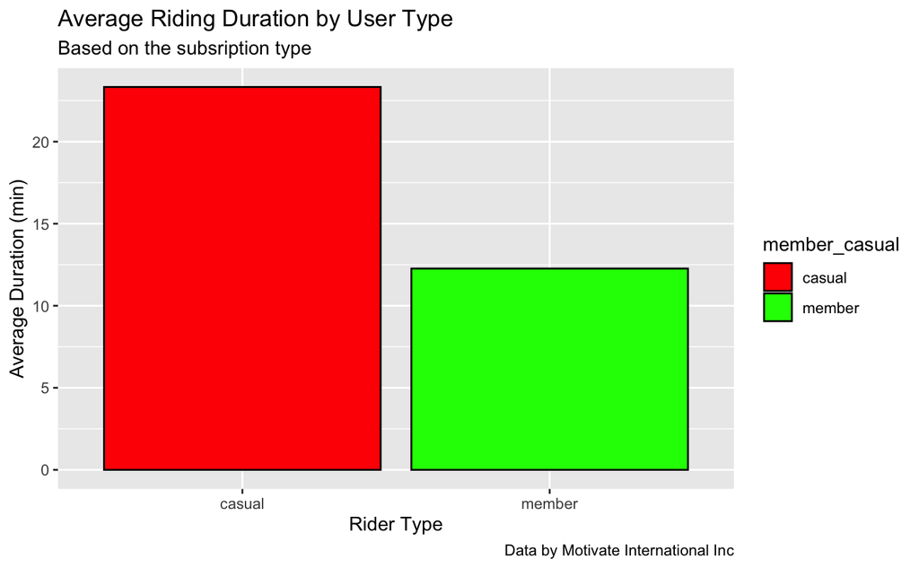

```r
clean_full_divvy_tripdata %>%
  group_by(member_casual) %>%
  summarize(average_duration = mean(ride_length/60)) %>%

ggplot(aes(x = member_casual, y = average_duration, fill = member_casual)) +
  geom_bar(stat = "identity", color = "black") +
  scale_fill_manual(values = c("casual" = "red", "member" = "green"))+
  labs(x = "Rider Type", y = "Average Duration (min)",
       title = "Average Riding Duration by User Type", subtitle = "Based on the subsription type",
       caption = "Data by Motivate International Inc")
```

### Analysis

#### Average riding duration between casual and member riders per day of the week

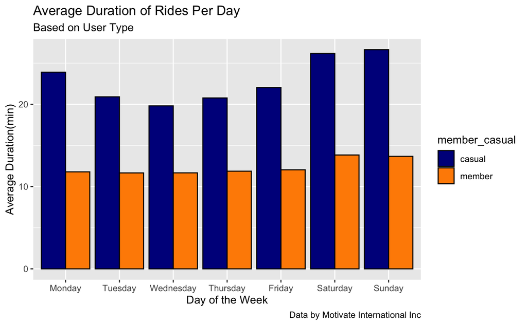

```r
clean_full_divvy_tripdata %>%
  mutate(day_of_week = factor(day_of_week,
                              levels = c("Monday", "Tuesday", "Wednesday", "Thursday", "Friday", "Saturday", "Sunday"))) %>%
  group_by(day_of_week, member_casual)%>%
  summarise(average_ride_duration = mean(ride_length/60))%>%
ggplot(aes(x = day_of_week, y = average_ride_duration, fill = member_casual)) +
  geom_bar(stat = "identity", color = "black", position = position_dodge()) +
  scale_fill_manual(values = c("casual" = "#00008B", member = "#FF8C00"))+
  labs(x = "Day of the Week", y = "Average Duration(min)",
       title = "Average Duration of Rides Per Day", subtitle = "Based on User Type",
       caption = " Data by Motivate International Inc")
```

#### Analysis

- From the Average Ride Duration Per Day;
- We can notice that casual users spend longer periods of time in general using the bikes each day,
- But we also can tell that the most dominant days are mostly the weekends, where the use the bikes for longer, more than 25 minutes
- During the workdays monday is the highly used day just right under 25 minutes.
- Whiles annual members use the bikes for less periods of time, usage remain fairly constant for ride duration through out the workdays, but we notice a slight increment in ride time during the weekends too.

### Analyzing the total number of rides by user types per day

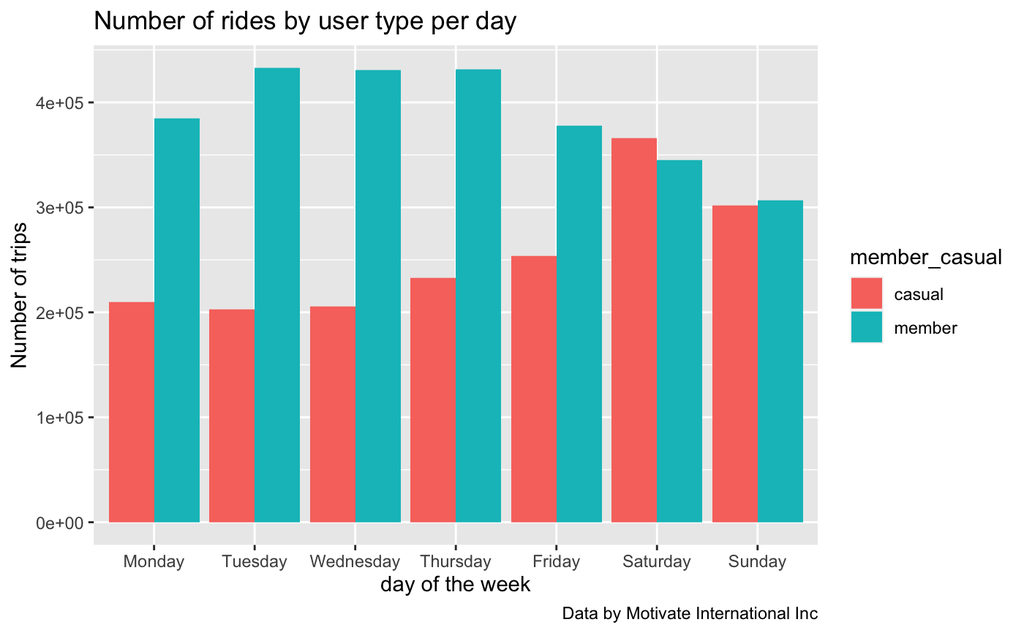

```r
clean_full_divvy_tripdata %>%
  mutate(day_of_week = factor(day_of_week,
                              levels = c("Monday", "Tuesday", "Wednesday", "Thursday", "Friday", "Saturday", "Sunday"))) %>%
  group_by(member_casual, day_of_week)%>%
  summarise(number_of_rides=n(),average_duration=mean(ride_length))%>%
  arrange(member_casual, day_of_week)%>%
  ggplot(aes(x=day_of_week,y=number_of_rides,fill=member_casual))+
  geom_bar(stat = "identity", position = position_dodge())+
  labs(x = "day of the week", y = "Number of trips", title = "Number of rides by user type per day",
       caption = "Data by Motivate International Inc")
```

#### More editing

You can use the geom_text() function in ggplot2 to add labels to your bars. The vjust argument adjusts the vertical positioning of the labels, and the position argument uses position_dodge() to align the labels with the bars. Here’s how:

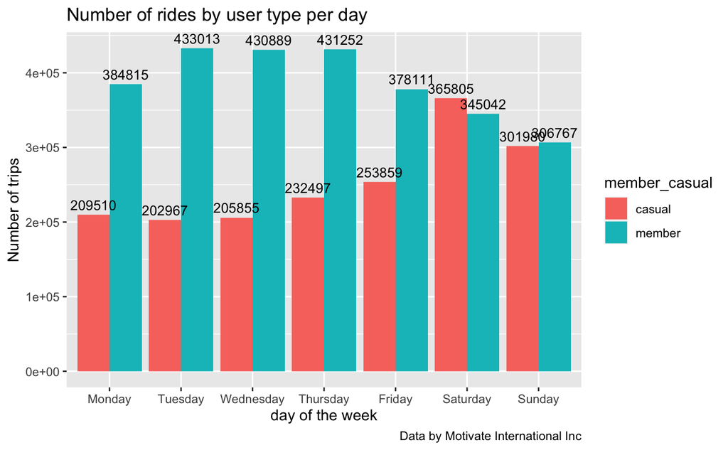

```r
clean_full_divvy_tripdata %>%
  mutate(day_of_week = factor(day_of_week,
                              levels = c("Monday", "Tuesday", "Wednesday", "Thursday", "Friday", "Saturday", "Sunday"))) %>%
  group_by(member_casual, day_of_week)%>%
  summarise(number_of_rides=n(),average_duration=mean(ride_length))%>%
  arrange(member_casual, day_of_week)%>%
  ggplot(aes(x=day_of_week,y=number_of_rides,fill=member_casual))+
  geom_bar(stat = "identity", position = position_dodge())+
  geom_text(aes(label=number_of_rides), vjust=-0.5, position = position_dodge(width=0.9), size=3.5, color="black")+
  labs(x = "day of the week", y = "Number of trips", title = "Number of rides by user type per day",
       caption = "Data by Motivate International Inc")
```

```r
NA
```

## Stage 6: Share

### Recommendation

Based on the analysis, we can provide the following recommendations to Cyclistic stakeholders:

- Annual members and casual riders use Cyclistic bikes differently in terms of ride duration and usage patterns. Casual riders tend to use the bikes for longer periods of time, particularly on weekends, while annual members use the bikes for shorter periods of time, mainly on weekdays. To increase the number of annual memberships, Cyclistic should focus on providing incentives to encourage casual riders to use the bikes more frequently on weekdays.
- Casual riders may be incentivized to purchase Cyclistic annual memberships if they perceive value in the benefits of membership, such as access to special events, discounts on bike accessories or extended rental time. Cyclistic should consider offering exclusive deals and discounts to annual members to entice casual riders to become members.
- Cyclistic can use digital media to influence casual riders to become members by showcasing the benefits of annual memberships, such as cost savings and access to special events. Cyclistic can create targeted social media campaigns and email marketing campaigns to reach potential customers who have previously rented bikes as casual riders. These campaigns should highlight the benefits of annual memberships and provide clear calls-to-action to encourage users to sign up for memberships. Additionally, Cyclistic can use data analysis to identify popular bike routes and optimize their marketing efforts to reach potential customers along those routes.

### In conclusion

By understanding the differences between annual members and casual riders, Cyclistic can develop targeted marketing strategies that encourage casual riders to become annual members. By leveraging digital media and offering incentives, the company can increase the number of annual memberships and drive its future growth and profitability.